# Lasso, Ridge, Elastic Net for Prediction

VC

April 25, 2016

# Good Prediction and Good Approximation of Reg Function Are Equivalent Problems

# Overview of Penalized Regression Methods for Prediction

Interested in prediction in the linear model: $Y_i = X_i'\beta_0 + \epsilon_i.$ The generic predictor will be of the form $\hat Y_i = X_i'\hat \beta$.

- The idea of penalized regression is to avoid overfitting in the sample by penalizing the size of the model through various norms of coefficients.
- The level of penalization ideally should be picked to approximately minimize the Mean Squared Error: $\text{MSE} = \mathbb{E} (Y_i - \hat Y_i)^2.$

# Lasso

Normalize $X_i$’s so that the second empirical moment is 1 for each component, namely $\frac{1}{n} \sum X^2_{ij} =1$. Otherwise need to modify penalty function to get equivariance to rescaling of components.

- LASSO solves:

$\hat{\beta}(\lambda)=\arg \min_{\beta \in \mathbb{R}^p} \sum (Y_i - X_{i}'\beta)^2 + \lambda ||\beta||_1$

Choice of penalty level $\lambda$:

– cross-validation (not justified theoretically but works well), implemented in $\mathbf{glmnet}$,

– plug-in method (Belloni et al) (justified theoretically and works well in practice), implemented in $\mathbf{hdm}.$

– produces a sparse model/ does dimension reduction

LASSO is very good for approximately sparse models.

# Post-Lasso

- POST-LASSO

– refit OLS after Lasso (justified theoretically and works well in practice).  
Choice of penalty level $\lambda$:

– cross-validation (not justified theoretically but works well);

– plug-in method (Belloni et al) (justified theoretically and works well in practice), implemented in $\mathbf{hdm}.$

Post-LASSO is very good for approximately sparse models.

# RIDGE

$\hat{\beta}(\lambda)=\arg \min_{\beta \in \mathbb{R}^p} \sum (Y_i - X_{i}'\beta)^2 + \lambda ||\beta||^2_2$

Choice of penalty level:

– cross-validation (not yet justified theoretically but works well) and

– Very good for models with many small coefficients.

– Ridge fit is never sparse; does not do variable selection.

# ELASTIC NET

$\hat{\beta}(\lambda_1, \lambda_2)=\arg \min_{\beta \in \mathbb{R}^p} \sum (Y_i - X_{i}'\beta)^2 + \lambda_1 ||\beta||^2_2 + \lambda_2 ||\beta||_1$

Choice of penalty level:

– cross-validation (not justified theoretically but works well) and plug-in method CV implemented in $\mathbf{glmnet}$.

– Interpolates between ridge and lasso.

– Elastic net produces a sparse model (unless $\lambda_2 =0$).

# LAVA

$\hat{\beta}(\lambda_1, \lambda_2)= ( \hat{\gamma}(\lambda_1, \lambda_2) + \hat{\delta}(\lambda_1, \lambda_2)) = \arg \min_{\gamma + \delta \in \mathbb{R}^p} \sum (Y_i - X_{i}'(\gamma + \delta))^2 + \lambda_1 ||\gamma||^2_2 + \lambda_2 ||\delta ||_1$

– Choice of penalty level: cross-validation (not justified theoretically but works well). Interpolates between ridge and lasso.

– Allows $\textbf{sparse + dense}$ coefficients. $\beta_0 = \underbrace{\gamma_0}_{\text{dense}} +\underbrace{\delta_0}_{\text{sparse}}.$

– Some coefficients can be large and some can be small for LAVA to work well.

– Lava never produces a sparse model.

# Set-up a Monte-Carlo Example

```r
options(warn=-1,message=-1)
library(glmnet)  # Package to fit ridge/lasso/elastic net models
library(hdm) # Package to fit lasso "rigorously"
library(randomForest)
library(rpart)
library(rpart.plot)
set.seed(1)  # Set seed for reproducibility
n <- 200  # Number of observations
p <- 300  # Number of predictors included in model
beta<- c(4/(1:p)^2)
x <- matrix(rnorm(n*p), nrow=n, ncol=p)
y <- x%*%beta + rnorm(n)*4
R2<- var(x%*%beta)/var(y)
R2
```

```
##           [,1]
## [1,] 0.5107271
```

# Approximately Sparse Model

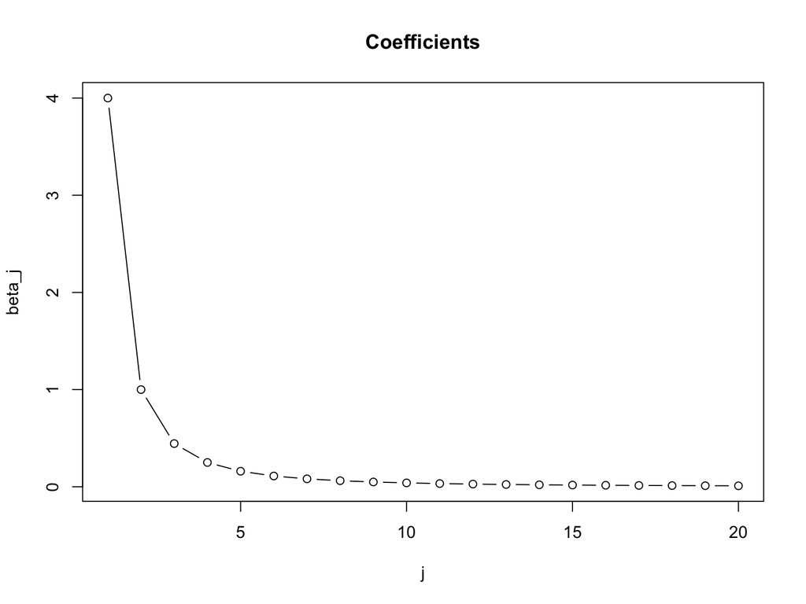

```r
plot(1:20, beta[1:20], type="bar", xlab="j", ylab="beta_j", main="Coefficients")
```

# Split Data into Training and Test Sets

```r
# Split data into train (1/2) and test (1/2) sets
train_rows <- sample(1:n, .5*n)
x.train <- x[train_rows, ]
x.test <- x[-train_rows, ]

y.train <- y[train_rows]
y.test <- y[-train_rows]
```

# Fit Lasso, Ridge, Elastic Net

```r
fit.rlasso<- rlasso(y.train~x.train)
fit.rlasso2<- rlasso(y.train~x.train, post=FALSE)
fit.lasso <- cv.glmnet(x.train, y.train, family="gaussian", alpha=1)
fit.ridge <- cv.glmnet(x.train, y.train, family="gaussian", alpha=0)
fit.elnet <- cv.glmnet(x.train, y.train, family="gaussian", alpha=.5)
```

# Plotting for GLMNET

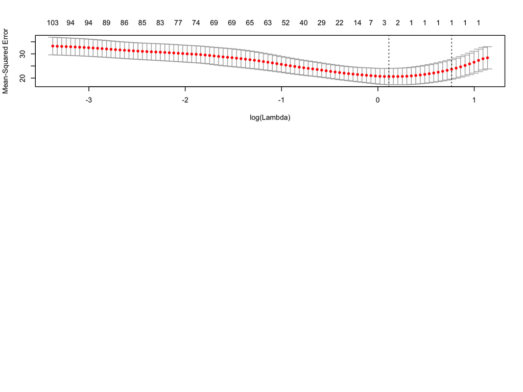

```r
par(mfrow=c(3,1))
plot(fit.lasso)
#plot(fit.ridge)
#plot(fit.elnet)
```